# Building Cox models for censored data (constant covariates)

Samuel Messa

December 17, 2019

## Data prep

The dataset concerns itself with a trial from the Mayo Clinic of the liver conducted between years 1974 and 1984. There are 418 patients in total with 312 cases participating in the randomized trial and additional 106 cases who did not participate in the clinical trial, but consented to have basic measurements recorded and to be followed for survival.

We begin by loading necessary libraries.

```r
library(survival)
library(survminer)
library(ggfortify)
library(muhaz)
library(tidyverse)
library(magrittr)
library(knitr)
library(texreg)
```

Next, we prepare the dataset.

- Factorizing variables *treatement*, *sex* and *edema*.
- Creating variable *delta* indicating whether the patient died.
- Dropping the variable *id*.

```r
pbc <- survival::pbc[, c("time", "status", "trt", "sex", "edema", "bili", "albumin", "platelet")]
categorical_vars <- c("trt", "sex", "edema")
pbc %<>%
  mutate(
    delta = (status == 2),
    high_bili = bili >= median(bili)
    )
pbc %<>%
  mutate_at(categorical_vars,factor)
levels(pbc$trt) <- c("Penicilin","Placebo")
pbc$trt %<>% relevel(ref = "Placebo")
levels(pbc$edema) <- c("None","UntreatedOrSucess","TreatmentFailed")
```

# Task 1

In this task we will explore the binary variables *sex* and the newly created variable $\textit{high_bili} = \mathbf{1}(bili \geq median(bili))$.

### Variable Sex

First we plot the Kaplan-Meier, Nelson-Aalen, and smoothed hazard estimates for males and females individually.

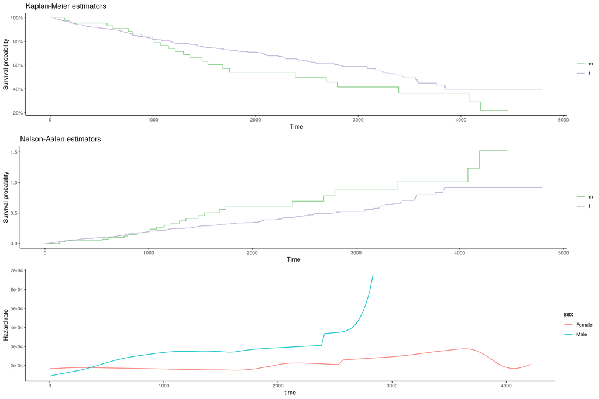

```r
pbc_fit_sex <- pbc %>% survfit(formula = Surv(time = time,event = delta) ~ sex)
km_sex <- pbc_fit_sex %>%
  autoplot(conf.int = FALSE, main = "Kaplan-Meier estimators",censor = FALSE) +
  scale_color_brewer("", palette = "Accent") +
  scale_fill_brewer("", palette = "Accent") +
  xlab("Time") +
  ylab("Survival probability") +
  theme_classic()
na_sex <- pbc_fit_sex %>%
  autoplot(conf.int = FALSE, fun="cumhaz", main = "Nelson-Aalen estimators",censor = FALSE) +
  scale_color_brewer("", palette = "Accent") +
  scale_fill_brewer("", palette = "Accent") +
  xlab("Time") +
  ylab("Survival probability") +
  theme_classic()

smooth_all <- pbc %$% muhaz(time,delta)
pbc_male <- pbc %>% filter(sex=="m") %$% muhaz(time,delta)
pbc_female <- pbc %>% filter(sex=="f") %$% muhaz(time,delta)

sh_sex_df <- rbind(
    tibble(
      time = pbc_male$est.grid,
      value = pbc_male$haz.est,
      sex ="Male"
      ),
    tibble(
      time = pbc_female$est.grid,
      value = pbc_female$haz.est,
      sex ="Female"
      )
    )
sh_sex <- sh_sex_df %>%
  ggplot() +
  geom_line(aes(x = time, y = value, color = sex))+
  ylab("Hazard rate")+
  theme_classic()

ggarrange(km_sex,na_sex,sh_sex,ncol = 1)
```

The assumption of proportional hazards could be considered justified. Especially if we consider, that the smoothed hazard estimates for male patients is likely not that precise for higher times due to the lower number of observations for male patients.

Next, we present the results of the log-rank test with the null being equality of the survival function (or equivalently cumulative hazards) for male and female patients. We do not reject the null at the significance level $\alpha = 0.05$.

```r
pbc %>% FHtest::FHtestrcc(formula = Surv(time,delta)~sex,data = .)
```

```
##
##  Two-sample test for right-censored data
##
## Parameters: rho=0, lambda=0
## Distribution: counting process approach
##
## Data: Surv(time, delta) by sex
##
##         N Observed Expected   O-E (O-E)^2/E (O-E)^2/V
## sex=f 374      137    143.7 -6.75     0.317      2.98
## sex=m  44       24     17.3  6.75     2.640      2.98
##
## Statistic Z= 1.7, p-value= 0.0845
## Alternative hypothesis: survival functions not equal
```

### Variable HighBili

We continue with plotting the Kaplan-Meier, Nelson-Aalen, and smoothed hazard estimates for patients having higher/lower levels of bilirubin than the median across both groups.

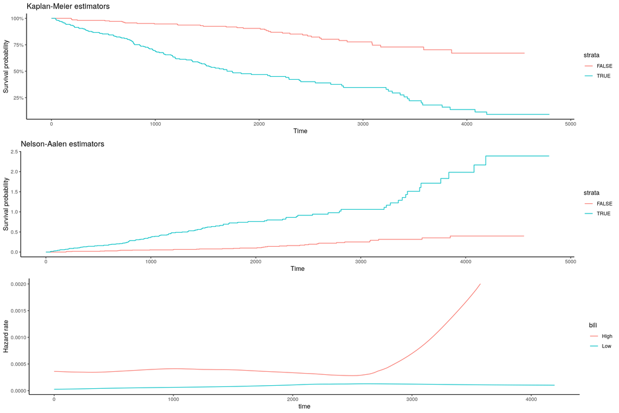

```r
pbc_fit_high_bili <- pbc %>% survfit(formula = Surv(time = time,event = delta) ~ high_bili)
km_high_bili <- pbc_fit_high_bili %>%
  autoplot(conf.int = FALSE, main = "Kaplan-Meier estimators",censor = FALSE) +
  xlab("Time") +
  ylab("Survival probability") +
  theme_classic()
na_high_bili <- pbc_fit_high_bili %>%
  autoplot(conf.int = FALSE, fun="cumhaz", main = "Nelson-Aalen estimators",censor = FALSE) +
  xlab("Time") +
  ylab("Survival probability") +
  theme_classic()

smooth_high_bili <- pbc %$% muhaz(time,delta)
pbc_high_bili <- pbc %>% filter(high_bili) %$% muhaz(time,delta)
pbc_low_bili <- pbc %>% filter(!high_bili) %$% muhaz(time,delta)

sh_high_bili_df <- rbind(
    tibble(
      time = pbc_high_bili$est.grid,
      value = pbc_high_bili$haz.est,
      bili ="High"
      ),
    tibble(
      time = pbc_low_bili$est.grid,
      value = pbc_low_bili$haz.est,
      bili ="Low"
      )
    )
sh_high_bili <- sh_high_bili_df %>%
  ggplot() +
  geom_line(aes(x = time, y = value, color = bili))+
  ylab("Hazard rate")+
  theme_classic()

ggarrange(km_high_bili,na_high_bili,sh_high_bili,ncol = 1)
```

Next we present the results of the log-rank test with the null being equality of the survival function (or equivalently cumulative hazards) for patients with high/low levels of bilirubin. This time we reject the null at the significance level $\alpha = 0.05$.

```r
pbc %>% FHtest::FHtestrcc(formula = Surv(time,delta)~high_bili,data = .)
```

```
##
##  Two-sample test for right-censored data
##
## Parameters: rho=0, lambda=0
## Distribution: counting process approach
##
## Data: Surv(time, delta) by high_bili
##
##                   N Observed Expected   O-E (O-E)^2/E (O-E)^2/V
## high_bili=FALSE 208       37     97.9 -60.9      37.9      99.3
## high_bili=TRUE  210      124     63.1  60.9      58.8      99.3
##
## Statistic Z= 10, p-value= 0
## Alternative hypothesis: survival functions not equal
```

# Task 2

### Variable Treatment

In this section a Cox proportional hazard with a single covariate *treatment* is fitted. The estimated coefficient can be interpreted as follows:
$$\begin{align}
\exp \beta_{\text{penicilin}} = \dfrac{\lambda(t| \mathbf{Z} + \mathbf{e}_j)}{\lambda(t| \mathbf{Z})}
\end{align}$$

More specifically, the hazard of patients given Penicillin is $\exp \beta_{\text{penicilin}} = 1.05889$ times higher, than in patients given placebo.

The confidence interval for $\exp \beta_{\text{penicilin}}$ is $(0.7453, 1.504)$. Its interpretation is analogous to confidence intervals for coefficients in classical regression models i.e. the interval provides coverage of the exponated coefficient with at the specified level $1-\alpha$.

Next we plot the estimated survival functions for both groups based on the Cox model compared with Kaplan-Meier estimators of the corresponding two samples.

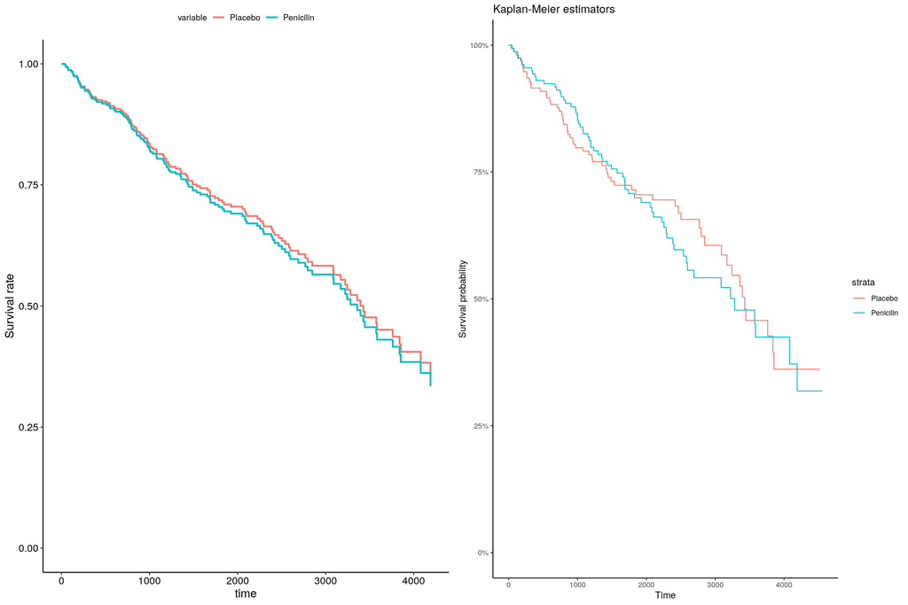

```r
trt_fit <- coxph(formula = Surv(time,delta)~trt, data = pbc)
trt_cox_plot <- ggadjustedcurves(trt_fit,variable = "trt",method = "average",data = pbc)
trt_km_plot <- survfit(Surv(time,delta)~trt,data = pbc) %>%
  autoplot(conf.int = FALSE, main = "Kaplan-Meier estimators",censor = FALSE) +
  xlab("Time") +
  ylab("Survival probability") +
  theme_classic() +
  expand_limits(y = c(0,1))
ggarrange(trt_cox_plot$plot_env$pl,trt_km_plot,ncol = 2)
```

Comparing the two plots, we immediately see that the non-parametric KM estimates seem to cross each other. This could indicate that the variable *trt* does not in fact satisfy the proportional hazard assumption.

Lastly, we compare the output of the fitted model with a log-rank test with the null being the equality of cumulative hazards between patients given penicillin and patients given the placebo. As we can see, the test is equivalent to testing the significance of coefficient *trtPenicilin*. Both do not reject the null of equality of cumulative hazards.

```r
trt_fit%>% summary()
```

```
## Call:
## coxph(formula = Surv(time, delta) ~ trt, data = pbc)
##
##   n= 312, number of events= 125
##    (106 observations deleted due to missingness)
##
##                 coef exp(coef) se(coef)     z Pr(>|z|)
## trtPenicilin 0.05722   1.05889  0.17916 0.319    0.749
##
##              exp(coef) exp(-coef) lower .95 upper .95
## trtPenicilin     1.059     0.9444    0.7453     1.504
##
## Concordance= 0.499  (se = 0.025 )
## Likelihood ratio test= 0.1  on 1 df,   p=0.7
## Wald test            = 0.1  on 1 df,   p=0.7
## Score (logrank) test = 0.1  on 1 df,   p=0.7
```

```r
pbc %>% FHtest::FHtestrcc(formula = Surv(time,delta)~trt,data = .)
```

```
##
##  Two-sample test for right-censored data
##
## Parameters: rho=0, lambda=0
## Distribution: counting process approach
##
## Data: Surv(time, delta) by trt
##
##                 N Observed Expected   O-E (O-E)^2/E (O-E)^2/V
## trt=Penicilin 158       65     63.2  1.78    0.0502     0.102
## trt=Placebo   154       60     61.8 -1.78    0.0513     0.102
##
## Statistic Z= -0.3, p-value= 0.75
## Alternative hypothesis: survival functions not equal
```

### Variable BiliRubin

In this section a Cox proportional hazard with a single covariate (*BiliQuant* defined as the variable *bili* cut by sample quartiles) is fitted.

The estimated coefficients corresponding to the given quartiles can be interpreted as follows: the hazard of patients having the levels of bilirubin in the given quartile is $\exp \beta_{\text{quartile}}$ times higher than in patients with bilirubin levels in the first quartile.

```r
pbc %<>% mutate(BiliQuant = gtools::quantcut(bili))
bili_fit <- coxph(formula = Surv(time,delta)~BiliQuant, data = pbc)
bili_fit %>% summary()
```

```
## Call:
## coxph(formula = Surv(time, delta) ~ BiliQuant, data = pbc)
##
##   n= 418, number of events= 161
##
##                       coef exp(coef) se(coef)     z Pr(>|z|)
## BiliQuant(0.8,1.4]  0.6025    1.8268   0.3121 1.931   0.0535 .
## BiliQuant(1.4,3.4]  1.4904    4.4389   0.2798 5.326    1e-07 ***
## BiliQuant(3.4,28]   2.5245   12.4842   0.2690 9.384   <2e-16 ***
## ---
## Signif. codes:  0 '***' 0.001 '**' 0.01 '*' 0.05 '.' 0.1 ' ' 1
##
##                    exp(coef) exp(-coef) lower .95 upper .95
## BiliQuant(0.8,1.4]     1.827     0.5474    0.9909     3.368
## BiliQuant(1.4,3.4]     4.439     0.2253    2.5651     7.682
## BiliQuant(3.4,28]     12.484     0.0801    7.3685    21.152
##
## Concordance= 0.754  (se = 0.019 )
## Likelihood ratio test= 132.4  on 3 df,   p=<2e-16
## Wald test            = 122  on 3 df,   p=<2e-16
## Score (logrank) test = 162.3  on 3 df,   p=<2e-16
```

Next we plot the estimated survival functions for all 4 groups based on the Cox model compared with Kaplan-Meier estimators of the corresponding 4 samples.

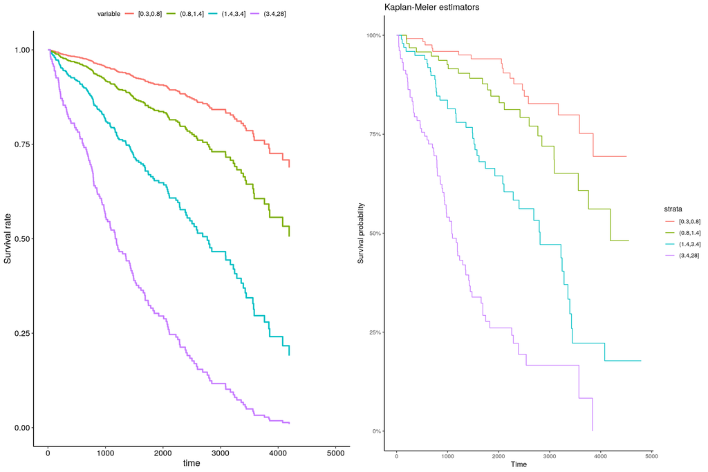

```r
bili_cox_plot <- ggadjustedcurves(bili_fit,variable = "BiliQuant",method = "average",data = pbc)
bili_km_plot <- survfit(Surv(time,delta)~BiliQuant,data = pbc) %>%
  autoplot(conf.int = FALSE, main = "Kaplan-Meier estimators",censor = FALSE) +
  xlab("Time") +
  ylab("Survival probability") +
  theme_classic() +
  expand_limits(y = c(0,1))
ggarrange(bili_cox_plot$plot_env$pl+ expand_limits(x = c(0,5000)),bili_km_plot,ncol = 2)
```

The plots are similar and the survival functions show clear difference for increasing values of *bilirubin*, reinforcing our intuition that the variable *bili* will be significant.

# Task 3

### Baseline additive model

In this section a Cox proportional hazard model for survival of PBC patients will be built. We first encode the missing values in variable *trt* as Non-randomized.

```r
pbc %<>%
  mutate(
    trt = forcats::fct_explicit_na(trt, "NonRandmized")
    )
```

Next a baseline model with the original variables is fitted.

```r
baseline_model <- pbc %>%
  coxph(formula = Surv(time = time,event = delta) ~ trt + sex + edema + bili + albumin + platelet, data = .)
baseline_model_summary <- baseline_model %>% summary()
baseline_model%>%
  htmlreg(
  single.row=TRUE,
  custom.model.names = c("Baseline Model"),
  override.coef = list(exp(baseline_model$coefficients)),
  include.rsquared = FALSE,
  include.adjrs = FALSE,
  include.maxrs = FALSE,
  ci.force = TRUE,
  override.ci.low = baseline_model_summary$conf.int[,3],
  override.ci.up = baseline_model_summary$conf.int[,4]
  )
```

Statistical models

|  | **Baseline Model** |  |
| --- | --- | --- |
| trtPenicilin | 1.21 [0.84; 1.75]* |  |
| trtNonRandmized | 1.10 [0.69; 1.76]* |  |
| sexf | 0.58 [0.37; 0.92]* |  |
| edemaUntreatedOrSucess | 1.39 [0.86; 2.24]* |  |
| edemaTreatmentFailed | 3.07 [1.66; 5.68]* |  |
| bili | 1.13 [1.10; 1.16]* |  |
| albumin | 0.33 [0.22; 0.51]* |  |
| platelet | 1.00 [1.00; 1.00]* |  |
| AIC | 1527.48 |  |
| Num. events | 155 |  |
| Num. obs. | 407 |  |
| Missings | 11 |  |
| PH test | 0.02 |  |
| * 0 outside the confidence interval |  |  |

### Variable parametrization

In order to gain insight on how to parametrize the numeric variables in our dataset we plot their estimated coefficients from the baseline model, where the numeric variable in questions is binned and treated as categorical.

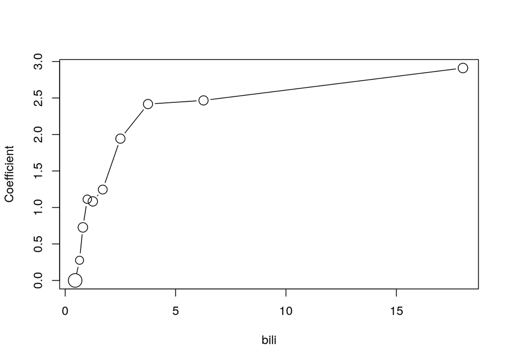

```r
variables <- c("bili", "albumin","platelet")
PlotCoefFactor <- function(variable, ngroups = 10){
  # ngroups >= 2 !!!!
  if(ngroups < 2){stop("ngroups has to be at least 2!")}
  othervar <- setdiff(variables, variable)
  qq <- quantile(pbc[,variable], probs = seq(0,1,length.out = ngroups+1),na.rm = TRUE)
  ff <- cut(pbc[,variable], breaks = c(-Inf, qq[2:ngroups], Inf))
  model <- pbc %>%
    add_column(ff) %>%
    coxph(formula = as.formula(paste("Surv(time = time,event = delta) ~ trt + sex + edema + ff + ", paste(setdiff(variables, variable), collapse = "+"), sep = "")), data = .)
  yy <- c(0, # coefficient for the first (reference group)
          model$coefficients[grep("ff", names(model$coefficients))])
  xx <- (qq[1:ngroups]+qq[2:(ngroups+1)])/2
  plot(yy ~ xx,
       type = "b",
       xlab = variable,
       ylab = "Coefficient",
       cex = summary(ff)/max(summary(ff))*2+0.5)
  }
PlotCoefFactor("bili")
```

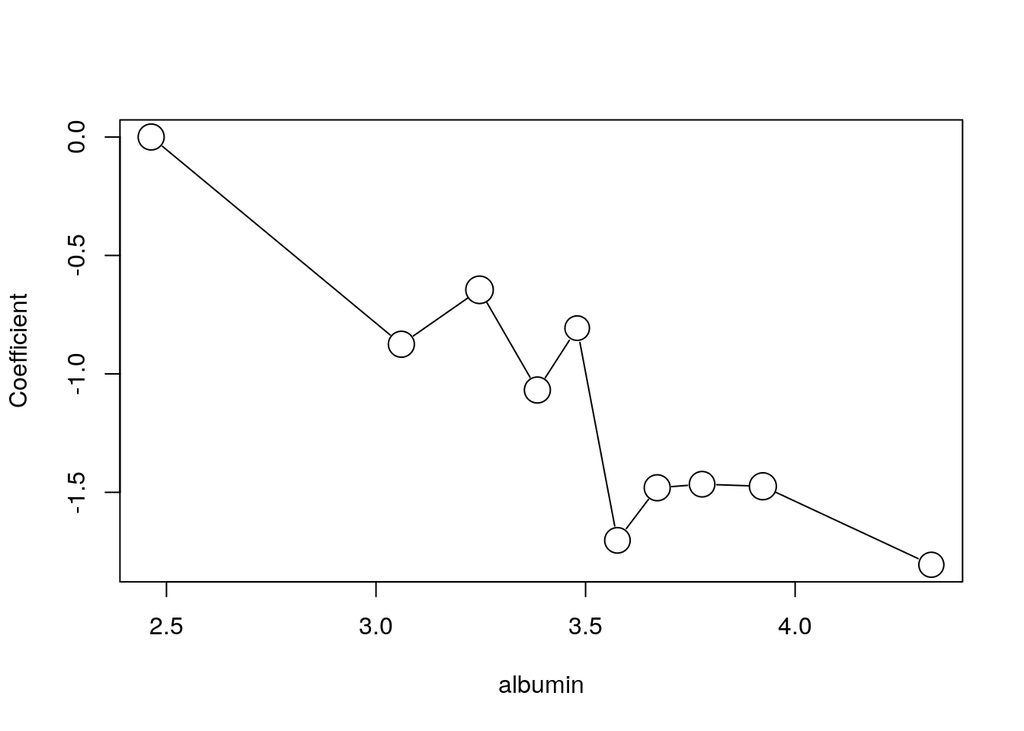

```r
PlotCoefFactor("albumin")
```

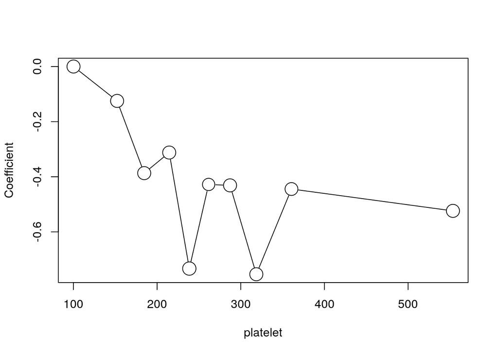

```r
PlotCoefFactor("platelet")
```

As we can see the variable *bili* clearly shows a logarithmic shape and the variables *albumin* and *platelet* are somewhat linear. Therefore we consider a model, where we apply a logarithmic transformation to *bili*.

### Final Model

```r
log_bili_model <- pbc %>%
  drop_na() %>%
  coxph(formula = Surv(time = time,event = delta) ~ trt + sex + edema + log(bili) + albumin + platelet, data = .)
log_bili_model_summary <- log_bili_model %>% summary()
log_bili_model%>%
  htmlreg(
  single.row=TRUE,
  custom.model.names = c("Baseline Model"),
  override.coef = list(exp(log_bili_model$coefficients)),
  include.rsquared = FALSE,
  include.adjrs = FALSE,
  include.maxrs = FALSE,
  ci.force = TRUE,
  override.ci.low = log_bili_model_summary$conf.int[,3],
  override.ci.up = log_bili_model_summary$conf.int[,4]
  )
```

Statistical models

|  | **Baseline Model** |  |
| --- | --- | --- |
| trtPenicilin | 1.08 [0.75; 1.56]* |  |
| trtNonRandmized | 1.04 [0.65; 1.65]* |  |
| sexf | 0.65 [0.41; 1.02]* |  |
| edemaUntreatedOrSucess | 1.53 [0.96; 2.45]* |  |
| edemaTreatmentFailed | 2.99 [1.65; 5.41]* |  |
| log(bili) | 2.34 [1.98; 2.77]* |  |
| albumin | 0.38 [0.25; 0.58]* |  |
| platelet | 1.00 [1.00; 1.00]* |  |
| AIC | 1487.67 |  |
| Num. events | 155 |  |
| Num. obs. | 407 |  |
| Missings | 0 |  |
| PH test | 0.17 |  |
| * 0 outside the confidence interval |  |  |

Additionally, we conduct likelihood ratio tests for sub-models for all considered covariates.

```r
drop1(log_bili_model,test = "Chisq")
```

```
## Single term deletions
##
## Model:
## Surv(time = time, event = delta) ~ trt + sex + edema + log(bili) +
##     albumin + platelet
##           Df    AIC    LRT  Pr(>Chi)
## <none>       1487.7
## trt        2 1483.8  0.168  0.919653
## sex        1 1488.8  3.161  0.075434 .
## edema      2 1496.5 12.792  0.001668 **
## log(bili)  1 1585.2 99.488 < 2.2e-16 ***
## albumin    1 1505.3 19.636 9.367e-06 ***
## platelet   1 1487.1  1.453  0.228101
## ---
## Signif. codes:  0 '***' 0.001 '**' 0.01 '*' 0.05 '.' 0.1 ' ' 1
```

Besides the variable *trt*, which needs to be kept in the model, the variable *platelet* is shown to not be significant. Therefore, it is removed from the model. This additionally allows us to utilize the 11 observations, where the variable *platelet* is missing.

```r
final_model <- pbc %>%
  coxph(formula = Surv(time = time,event = delta) ~ trt + sex + edema + log(bili) + albumin, data = .)
final_model_summary <- final_model %>%
  summary()
drop1(final_model,test = "Chisq")
```

```
## Single term deletions
##
## Model:
## Surv(time = time, event = delta) ~ trt + sex + edema + log(bili) +
##     albumin
##           Df    AIC     LRT  Pr(>Chi)
## <none>       1557.8
## trt        2 1553.9   0.145 0.9298608
## sex        1 1559.5   3.760 0.0525023 .
## edema      2 1571.1  17.344 0.0001713 ***
## log(bili)  1 1657.3 101.546 < 2.2e-16 ***
## albumin    1 1574.8  19.049 1.274e-05 ***
## ---
## Signif. codes:  0 '***' 0.001 '**' 0.01 '*' 0.05 '.' 0.1 ' ' 1
```

$$\begin{aligned}
\lambda(t| \mathbf{Z}) = \lambda_0(t) \text{ exp}(&\beta_{1} \times \mathbb{1} \left[trt = \text{penicilin} \right] + \\
&\beta_{2} \times \mathbb{1} \left[trt = \text{not randomized} \right] +\\
&\beta_{3} \times \mathbb{1} \left[sex = \text{female} \right] + \\
&\beta_{4} \times \mathbb{1} \left[edema = \text{untreated or sucess} \right] +\\
&\beta_{5} \times \mathbb{1} \left[edema = \text{treatment failed} \right] + \\
&\beta_{6} \times \log (\mathit{bili}) + \\
&\beta_{7} \times \mathit{albumin})
\end{aligned}$$

### Parametric model comparison

Lastly, we compare the newly fitted Cox PH model with the parametric model fitted in previous hw assignments, where we assumed that the survival times are exponentially distributed (conditionally on the covariates).

Statistical models

|  | **Cox PH Model** | **Parametric Model** |  |
| --- | --- | --- | --- |
| trtPenicilin | 1.05 [0.73; 1.52]* | 1.04 [0.73; 1.50]* |  |
| trtNonRandmized | 1.08 [0.70; 1.68]* | 1.02 [0.66; 1.57]* |  |
| sexf | 0.63 [0.40; 0.98]* | 0.64 [0.42; 1.02]* |  |
| edemaUntreatedOrSucess | 1.66 [1.05; 2.61]* | 1.66 [1.04; 2.55]* |  |
| edemaTreatmentFailed | 3.42 [1.94; 6.02]* | 3.00 [1.68; 5.14]* |  |
| log(bili) | 2.31 [1.96; 2.72]* | 2.03 [1.75; 2.37]* |  |
| albumin | 0.40 [0.26; 0.60]* | 0.50 [0.34; 0.74]* |  |
| (Intercept) |  | 0.00 [0.00; 0.01]* |  |
| AIC | 1557.78 | 704.85 |  |
| Num. events | 161 |  |  |
| Num. obs. | 418 | 418 |  |
| Missings | 0 |  |  |
| PH test | 0.18 |  |  |
| BIC |  | 737.14 |  |
| Log Likelihood |  | -344.43 |  |
| Deviance |  | 366.85 |  |
| * 0 outside the confidence interval |  |  |  |

The chosen coefficients and their parametrization remain the same. However, as expected an intercept term is not fitted for the Cox model.

The exponated coefficients are mostly in agreement with the only considerable difference being the coefficient corresponding to *edemaTreatmentFailed*, which is higher in the Cox Model.